# Articles for Deletion — what the discussions look like

```python
# who are they? samples of each participant class to look up by hand
from IPython.display import HTML, display

N, SEED = 25, 0
SHOW_E = ["n_discussions", "n_afd_edits", "first_afd_edit", "last_afd_edit", "afd_tenure_days"]
name = editors_w.index.str.replace(" ", "_")
ew = editors_w.assign(
    user_page="https://en.wikipedia.org/wiki/User:" + name,
    contribs="https://en.wikipedia.org/wiki/Special:Contributions/" + name + "?namespace=4",  # Wikipedia: pages only
)

samples = {
    "regular (top 25)": ew[ew.cls.eq("regular")].nlargest(N, "n_discussions"),
    "regular (random)": ew[ew.cls.eq("regular")].sample(N, random_state=SEED),
    "occasional":       ew[ew.cls.eq("occasional")].sample(N, random_state=SEED),
    "one_timer":        ew[ew.cls.eq("one_timer")].sample(N, random_state=SEED),
}
parts = []
for lab, t in samples.items():
    t = (t[SHOW_E + ["user_page", "contribs"]].sort_values("n_discussions", ascending=False)
          .round({"afd_tenure_days": 0}))
    parts.append(f"<h3>{lab}</h3>" + t.to_html(render_links=True, escape=True))
page = "\n".join(parts)
display(HTML(page))                                  # clickable in the notebook

with open("editor_samples.html", "w") as f:          # same tables, open in a browser
    f.write(f"<!doctype html><meta charset='utf-8'><title>AfD editor samples</title>"
            f"<style>body{{font-family:sans-serif;margin:16px}}table{{border-collapse:collapse;font-size:13px}}"
            f"td,th{{border:1px solid #ccc;padding:3px 6px}}</style>{page}")
```

regular (top 25)

| editor | n_discussions | n_afd_edits | first_afd_edit | last_afd_edit | afd_tenure_days | user_page | contribs |
| --- | --- | --- | --- | --- | --- | --- | --- |
| Gene93k | 83220 | 89485 | 2007-08-26 13:28:20 | 2025-01-06 00:08:09 | 6342.0 | https://en.wikipedia.org/wiki/User:Gene93k | https://en.wikipedia.org/wiki/Special:Contributions/Gene93k?namespace=4 |
| Northamerica1000 | 40719 | 51436 | 2011-08-09 09:22:33 | 2024-12-25 12:58:36 | 4887.0 | https://en.wikipedia.org/wiki/User:Northamerica1000 | https://en.wikipedia.org/wiki/Special:Contributions/Northamerica1000?namespace=4 |
| Spiderone | 25209 | 29766 | 2009-04-24 08:45:59 | 2025-01-24 23:48:52 | 5755.0 | https://en.wikipedia.org/wiki/User:Spiderone | https://en.wikipedia.org/wiki/Special:Contributions/Spiderone?namespace=4 |
| Liz | 25105 | 32097 | 2013-08-01 21:24:01 | 2025-01-24 22:34:13 | 4194.0 | https://en.wikipedia.org/wiki/User:Liz | https://en.wikipedia.org/wiki/Special:Contributions/Liz?namespace=4 |
| Sandstein | 24015 | 25989 | 2005-08-01 07:25:29 | 2025-01-23 18:07:28 | 7115.0 | https://en.wikipedia.org/wiki/User:Sandstein | https://en.wikipedia.org/wiki/Special:Contributions/Sandstein?namespace=4 |
| CAPTAIN RAJU | 23990 | 26857 | 2015-12-23 20:25:17 | 2025-01-19 21:44:09 | 3315.0 | https://en.wikipedia.org/wiki/User:CAPTAIN_RAJU | https://en.wikipedia.org/wiki/Special:Contributions/CAPTAIN_RAJU?namespace=4 |
| Johnpacklambert | 21898 | 22928 | 2007-07-02 16:36:20 | 2022-07-27 20:07:43 | 5504.0 | https://en.wikipedia.org/wiki/User:Johnpacklambert | https://en.wikipedia.org/wiki/Special:Contributions/Johnpacklambert?namespace=4 |
| DGG | 21401 | 24639 | 2006-11-26 23:58:13 | 2022-12-24 04:17:25 | 5871.0 | https://en.wikipedia.org/wiki/User:DGG | https://en.wikipedia.org/wiki/Special:Contributions/DGG?namespace=4 |
| Shellwood | 21034 | 21147 | 2017-05-12 14:29:19 | 2025-01-17 11:45:01 | 2807.0 | https://en.wikipedia.org/wiki/User:Shellwood | https://en.wikipedia.org/wiki/Special:Contributions/Shellwood?namespace=4 |
| Explicit | 19639 | 21936 | 2008-02-23 01:32:02 | 2025-01-24 23:58:22 | 6181.0 | https://en.wikipedia.org/wiki/User:Explicit | https://en.wikipedia.org/wiki/Special:Contributions/Explicit?namespace=4 |
| Mailer diablo | 17565 | 17972 | 2005-01-15 09:28:11 | 2024-08-29 21:20:41 | 7166.0 | https://en.wikipedia.org/wiki/User:Mailer_diablo | https://en.wikipedia.org/wiki/Special:Contributions/Mailer_diablo?namespace=4 |
| Ron Ritzman | 16213 | 17972 | 2007-03-09 01:08:34 | 2014-03-24 03:56:30 | 2572.0 | https://en.wikipedia.org/wiki/User:Ron_Ritzman | https://en.wikipedia.org/wiki/Special:Contributions/Ron_Ritzman?namespace=4 |
| GiantSnowman | 15528 | 17781 | 2006-11-26 13:58:11 | 2025-01-24 13:23:31 | 6634.0 | https://en.wikipedia.org/wiki/User:GiantSnowman | https://en.wikipedia.org/wiki/Special:Contributions/GiantSnowman?namespace=4 |
| Bearian | 15097 | 15901 | 2007-04-04 23:26:26 | 2025-01-23 06:08:34 | 6503.0 | https://en.wikipedia.org/wiki/User:Bearian | https://en.wikipedia.org/wiki/Special:Contributions/Bearian?namespace=4 |
| SwisterTwister | 14333 | 15518 | 2010-05-29 06:09:24 | 2017-12-14 07:23:08 | 2756.0 | https://en.wikipedia.org/wiki/User:SwisterTwister | https://en.wikipedia.org/wiki/Special:Contributions/SwisterTwister?namespace=4 |
| Cirt | 13925 | 14824 | 2007-10-16 04:24:22 | 2016-04-20 15:55:06 | 3109.0 | https://en.wikipedia.org/wiki/User:Cirt | https://en.wikipedia.org/wiki/Special:Contributions/Cirt?namespace=4 |
| David Eppstein | 12950 | 15328 | 2006-09-15 01:36:31 | 2025-01-24 19:04:52 | 6707.0 | https://en.wikipedia.org/wiki/User:David_Eppstein | https://en.wikipedia.org/wiki/Special:Contributions/David_Eppstein?namespace=4 |
| MBisanz | 12747 | 13501 | 2007-08-27 20:46:33 | 2022-05-01 17:21:27 | 5361.0 | https://en.wikipedia.org/wiki/User:MBisanz | https://en.wikipedia.org/wiki/Special:Contributions/MBisanz?namespace=4 |
| Shawn à Montréal | 11690 | 14287 | 2006-12-27 03:50:34 | 2022-08-15 15:36:23 | 5710.0 | https://en.wikipedia.org/wiki/User:Shawn_à_Montréal | https://en.wikipedia.org/wiki/Special:Contributions/Shawn_à_Montréal?namespace=4 |
| Stifle | 11495 | 11914 | 2005-11-11 18:59:12 | 2024-07-11 08:25:55 | 6817.0 | https://en.wikipedia.org/wiki/User:Stifle | https://en.wikipedia.org/wiki/Special:Contributions/Stifle?namespace=4 |
| Wcquidditch | 10682 | 10888 | 2005-09-25 22:48:56 | 2025-01-24 17:51:41 | 7061.0 | https://en.wikipedia.org/wiki/User:Wcquidditch | https://en.wikipedia.org/wiki/Special:Contributions/Wcquidditch?namespace=4 |
| TenPoundHammer | 9695 | 12699 | 2006-09-12 21:46:55 | 2022-07-25 15:27:54 | 5795.0 | https://en.wikipedia.org/wiki/User:TenPoundHammer | https://en.wikipedia.org/wiki/Special:Contributions/TenPoundHammer?namespace=4 |
| Bearcat | 9611 | 15085 | 2004-09-08 00:12:27 | 2025-01-24 18:37:22 | 7444.0 | https://en.wikipedia.org/wiki/User:Bearcat | https://en.wikipedia.org/wiki/Special:Contributions/Bearcat?namespace=4 |
| Coolabahapple | 9215 | 9847 | 2015-02-16 06:52:56 | 2022-06-24 07:36:17 | 2685.0 | https://en.wikipedia.org/wiki/User:Coolabahapple | https://en.wikipedia.org/wiki/Special:Contributions/Coolabahapple?namespace=4 |
| Whpq | 8637 | 10476 | 2006-05-09 16:51:28 | 2025-01-21 16:50:46 | 6832.0 | https://en.wikipedia.org/wiki/User:Whpq | https://en.wikipedia.org/wiki/Special:Contributions/Whpq?namespace=4 |

regular (random)

| editor | n_discussions | n_afd_edits | first_afd_edit | last_afd_edit | afd_tenure_days | user_page | contribs |
| --- | --- | --- | --- | --- | --- | --- | --- |
| Zxcvbnm | 2451 | 3519 | 2005-03-16 03:05:27 | 2025-01-20 01:41:28 | 7250.0 | https://en.wikipedia.org/wiki/User:Zxcvbnm | https://en.wikipedia.org/wiki/Special:Contributions/Zxcvbnm?namespace=4 |
| Extraordinary Writ | 2404 | 2575 | 2020-11-15 06:38:16 | 2025-01-17 09:01:40 | 1524.0 | https://en.wikipedia.org/wiki/User:Extraordinary_Writ | https://en.wikipedia.org/wiki/Special:Contributions/Extraordinary_Writ?namespace=4 |
| Mz7 | 2217 | 2464 | 2012-01-15 17:15:31 | 2024-09-18 09:29:43 | 4630.0 | https://en.wikipedia.org/wiki/User:Mz7 | https://en.wikipedia.org/wiki/Special:Contributions/Mz7?namespace=4 |
| Dennis Brown | 1961 | 2935 | 2007-07-22 17:43:32 | 2024-10-27 08:25:26 | 6307.0 | https://en.wikipedia.org/wiki/User:Dennis_Brown | https://en.wikipedia.org/wiki/Special:Contributions/Dennis_Brown?namespace=4 |
| Spinningspark | 1581 | 2371 | 2007-12-29 14:51:35 | 2023-02-16 19:48:41 | 5528.0 | https://en.wikipedia.org/wiki/User:Spinningspark | https://en.wikipedia.org/wiki/Special:Contributions/Spinningspark?namespace=4 |
| Hobit | 1362 | 2096 | 2007-03-01 18:23:06 | 2024-11-20 02:11:17 | 6473.0 | https://en.wikipedia.org/wiki/User:Hobit | https://en.wikipedia.org/wiki/Special:Contributions/Hobit?namespace=4 |
| Tevildo | 1159 | 1399 | 2006-06-06 15:57:53 | 2024-04-04 17:32:16 | 6512.0 | https://en.wikipedia.org/wiki/User:Tevildo | https://en.wikipedia.org/wiki/Special:Contributions/Tevildo?namespace=4 |
| Editorofthewiki | 1151 | 1289 | 2008-01-03 22:51:27 | 2025-01-05 17:26:43 | 6212.0 | https://en.wikipedia.org/wiki/User:Editorofthewiki | https://en.wikipedia.org/wiki/Special:Contributions/Editorofthewiki?namespace=4 |
| DarthVader | 1149 | 1180 | 2005-07-10 03:12:03 | 2006-08-12 08:19:28 | 398.0 | https://en.wikipedia.org/wiki/User:DarthVader | https://en.wikipedia.org/wiki/Special:Contributions/DarthVader?namespace=4 |
| Bonadea | 942 | 1347 | 2006-12-01 09:01:39 | 2025-01-11 15:45:45 | 6616.0 | https://en.wikipedia.org/wiki/User:Bonadea | https://en.wikipedia.org/wiki/Special:Contributions/Bonadea?namespace=4 |
| Lambiam | 922 | 1371 | 2006-02-03 05:04:31 | 2024-05-21 07:08:29 | 6682.0 | https://en.wikipedia.org/wiki/User:Lambiam | https://en.wikipedia.org/wiki/Special:Contributions/Lambiam?namespace=4 |
| Slatersteven | 770 | 1601 | 2008-01-01 19:49:10 | 2024-12-23 18:30:31 | 6201.0 | https://en.wikipedia.org/wiki/User:Slatersteven | https://en.wikipedia.org/wiki/Special:Contributions/Slatersteven?namespace=4 |
| Candleabracadabra | 708 | 871 | 2011-12-09 17:57:34 | 2014-05-26 23:00:11 | 899.0 | https://en.wikipedia.org/wiki/User:Candleabracadabra | https://en.wikipedia.org/wiki/Special:Contributions/Candleabracadabra?namespace=4 |
| Protonk | 588 | 950 | 2008-04-17 05:13:20 | 2022-09-04 22:13:32 | 5254.0 | https://en.wikipedia.org/wiki/User:Protonk | https://en.wikipedia.org/wiki/Special:Contributions/Protonk?namespace=4 |
| Fang Aili | 550 | 632 | 2005-08-23 20:00:14 | 2011-05-21 21:09:49 | 2097.0 | https://en.wikipedia.org/wiki/User:Fang_Aili | https://en.wikipedia.org/wiki/Special:Contributions/Fang_Aili?namespace=4 |
| Bongomatic | 537 | 932 | 2008-07-27 08:38:08 | 2018-10-20 07:27:43 | 3737.0 | https://en.wikipedia.org/wiki/User:Bongomatic | https://en.wikipedia.org/wiki/Special:Contributions/Bongomatic?namespace=4 |
| Jacqui M | 489 | 537 | 2005-09-08 05:46:26 | 2006-08-17 21:24:28 | 344.0 | https://en.wikipedia.org/wiki/User:Jacqui_M | https://en.wikipedia.org/wiki/Special:Contributions/Jacqui_M?namespace=4 |
| StarTrekker | 485 | 692 | 2016-01-20 22:24:32 | 2024-12-26 10:32:10 | 3263.0 | https://en.wikipedia.org/wiki/User:StarTrekker | https://en.wikipedia.org/wiki/Special:Contributions/StarTrekker?namespace=4 |
| Avilich | 471 | 817 | 2020-10-17 01:10:19 | 2023-08-26 16:00:11 | 1044.0 | https://en.wikipedia.org/wiki/User:Avilich | https://en.wikipedia.org/wiki/Special:Contributions/Avilich?namespace=4 |
| MarnetteD | 457 | 552 | 2007-06-04 14:29:30 | 2022-12-18 18:52:58 | 5676.0 | https://en.wikipedia.org/wiki/User:MarnetteD | https://en.wikipedia.org/wiki/Special:Contributions/MarnetteD?namespace=4 |
| Cyclopia | 451 | 941 | 2005-08-31 11:34:15 | 2025-01-22 09:49:16 | 7084.0 | https://en.wikipedia.org/wiki/User:Cyclopia | https://en.wikipedia.org/wiki/Special:Contributions/Cyclopia?namespace=4 |
| Bluerasberry | 434 | 551 | 2009-11-02 21:13:23 | 2024-12-12 20:58:01 | 5519.0 | https://en.wikipedia.org/wiki/User:Bluerasberry | https://en.wikipedia.org/wiki/Special:Contributions/Bluerasberry?namespace=4 |
| Texture | 429 | 487 | 2004-02-26 20:15:22 | 2011-09-01 22:49:12 | 2744.0 | https://en.wikipedia.org/wiki/User:Texture | https://en.wikipedia.org/wiki/Special:Contributions/Texture?namespace=4 |
| SafariScribe | 427 | 648 | 2024-01-15 15:03:23 | 2025-01-20 20:40:59 | 371.0 | https://en.wikipedia.org/wiki/User:SafariScribe | https://en.wikipedia.org/wiki/Special:Contributions/SafariScribe?namespace=4 |
| BilledMammal | 420 | 813 | 2019-09-20 07:21:08 | 2024-10-20 22:24:49 | 1858.0 | https://en.wikipedia.org/wiki/User:BilledMammal | https://en.wikipedia.org/wiki/Special:Contributions/BilledMammal?namespace=4 |

occasional

| editor | n_discussions | n_afd_edits | first_afd_edit | last_afd_edit | afd_tenure_days | user_page | contribs |
| --- | --- | --- | --- | --- | --- | --- | --- |
| Tulkolahten | 112 | 203 | 2006-10-09 22:26:04 | 2008-03-21 20:03:44 | 529.0 | https://en.wikipedia.org/wiki/User:Tulkolahten | https://en.wikipedia.org/wiki/Special:Contributions/Tulkolahten?namespace=4 |
| Chris 73 | 70 | 96 | 2004-10-31 10:07:26 | 2012-09-18 17:52:54 | 2879.0 | https://en.wikipedia.org/wiki/User:Chris_73 | https://en.wikipedia.org/wiki/Special:Contributions/Chris_73?namespace=4 |
| Wikipedian, Historian, and Friend? | 43 | 45 | 2006-12-14 21:01:39 | 2007-04-10 20:56:38 | 117.0 | https://en.wikipedia.org/wiki/User:Wikipedian,_Historian,_and_Friend? | https://en.wikipedia.org/wiki/Special:Contributions/Wikipedian,_Historian,_and_Friend??namespace=4 |
| Wiccan Quagga | 17 | 17 | 2005-06-19 09:37:27 | 2006-04-16 05:40:50 | 301.0 | https://en.wikipedia.org/wiki/User:Wiccan_Quagga | https://en.wikipedia.org/wiki/Special:Contributions/Wiccan_Quagga?namespace=4 |
| AaronSw | 8 | 9 | 2003-10-26 04:29:43 | 2006-01-02 04:32:36 | 799.0 | https://en.wikipedia.org/wiki/User:AaronSw | https://en.wikipedia.org/wiki/Special:Contributions/AaronSw?namespace=4 |
| Nishadhi | 8 | 9 | 2012-11-30 17:08:13 | 2015-06-27 14:17:25 | 939.0 | https://en.wikipedia.org/wiki/User:Nishadhi | https://en.wikipedia.org/wiki/Special:Contributions/Nishadhi?namespace=4 |
| Naue7 | 7 | 7 | 2015-02-25 04:44:23 | 2022-09-21 21:50:37 | 2766.0 | https://en.wikipedia.org/wiki/User:Naue7 | https://en.wikipedia.org/wiki/Special:Contributions/Naue7?namespace=4 |
| Elaich | 6 | 12 | 2005-11-16 05:43:06 | 2008-03-10 17:43:00 | 845.0 | https://en.wikipedia.org/wiki/User:Elaich | https://en.wikipedia.org/wiki/Special:Contributions/Elaich?namespace=4 |
| SoniaSotomayorFan | 6 | 7 | 2023-07-22 22:35:12 | 2023-08-01 19:16:27 | 10.0 | https://en.wikipedia.org/wiki/User:SoniaSotomayorFan | https://en.wikipedia.org/wiki/Special:Contributions/SoniaSotomayorFan?namespace=4 |
| AquitaneHungerForce | 5 | 7 | 2020-07-04 00:59:19 | 2024-10-13 13:03:12 | 1563.0 | https://en.wikipedia.org/wiki/User:AquitaneHungerForce | https://en.wikipedia.org/wiki/Special:Contributions/AquitaneHungerForce?namespace=4 |
| Macor822 | 5 | 5 | 2021-08-27 00:46:28 | 2021-08-27 00:46:41 | 0.0 | https://en.wikipedia.org/wiki/User:Macor822 | https://en.wikipedia.org/wiki/Special:Contributions/Macor822?namespace=4 |
| Solution55 | 4 | 6 | 2013-05-02 08:41:27 | 2013-05-08 09:39:08 | 6.0 | https://en.wikipedia.org/wiki/User:Solution55 | https://en.wikipedia.org/wiki/Special:Contributions/Solution55?namespace=4 |
| RenniePet | 4 | 13 | 2008-01-07 18:02:42 | 2008-05-04 11:13:42 | 118.0 | https://en.wikipedia.org/wiki/User:RenniePet | https://en.wikipedia.org/wiki/Special:Contributions/RenniePet?namespace=4 |
| Bully Wee | 4 | 5 | 2008-07-31 10:27:51 | 2010-06-06 23:54:00 | 676.0 | https://en.wikipedia.org/wiki/User:Bully_Wee | https://en.wikipedia.org/wiki/Special:Contributions/Bully_Wee?namespace=4 |
| Trvsdrlng | 4 | 5 | 2007-11-14 22:40:15 | 2010-10-20 19:26:35 | 1071.0 | https://en.wikipedia.org/wiki/User:Trvsdrlng | https://en.wikipedia.org/wiki/Special:Contributions/Trvsdrlng?namespace=4 |
| Kurtan~enwiki | 3 | 4 | 2006-07-13 12:10:20 | 2010-12-23 20:57:30 | 1624.0 | https://en.wikipedia.org/wiki/User:Kurtan~enwiki | https://en.wikipedia.org/wiki/Special:Contributions/Kurtan~enwiki?namespace=4 |
| Veldsenk | 3 | 3 | 2024-12-11 19:19:08 | 2025-01-19 15:32:50 | 39.0 | https://en.wikipedia.org/wiki/User:Veldsenk | https://en.wikipedia.org/wiki/Special:Contributions/Veldsenk?namespace=4 |
| Spoilydoily | 3 | 11 | 2008-07-25 13:15:14 | 2008-10-06 12:52:09 | 73.0 | https://en.wikipedia.org/wiki/User:Spoilydoily | https://en.wikipedia.org/wiki/Special:Contributions/Spoilydoily?namespace=4 |
| Redsur | 2 | 2 | 2008-09-29 12:47:37 | 2008-09-29 14:31:48 | 0.0 | https://en.wikipedia.org/wiki/User:Redsur | https://en.wikipedia.org/wiki/Special:Contributions/Redsur?namespace=4 |
| Wikivanda199 | 2 | 2 | 2009-05-04 15:44:07 | 2009-05-29 16:01:15 | 25.0 | https://en.wikipedia.org/wiki/User:Wikivanda199 | https://en.wikipedia.org/wiki/Special:Contributions/Wikivanda199?namespace=4 |
| John Gibbons 3 | 2 | 5 | 2011-01-15 16:55:43 | 2020-02-18 12:33:12 | 3321.0 | https://en.wikipedia.org/wiki/User:John_Gibbons_3 | https://en.wikipedia.org/wiki/Special:Contributions/John_Gibbons_3?namespace=4 |
| Markus Schweiss~enwiki | 2 | 3 | 2005-10-07 12:45:40 | 2007-02-27 05:29:51 | 508.0 | https://en.wikipedia.org/wiki/User:Markus_Schweiss~enwiki | https://en.wikipedia.org/wiki/Special:Contributions/Markus_Schweiss~enwiki?namespace=4 |
| DmanDmythDledge | 2 | 2 | 2007-04-11 17:54:53 | 2008-06-06 14:43:10 | 422.0 | https://en.wikipedia.org/wiki/User:DmanDmythDledge | https://en.wikipedia.org/wiki/Special:Contributions/DmanDmythDledge?namespace=4 |
| Billfred | 2 | 2 | 2006-08-16 02:36:02 | 2007-01-30 23:39:07 | 168.0 | https://en.wikipedia.org/wiki/User:Billfred | https://en.wikipedia.org/wiki/Special:Contributions/Billfred?namespace=4 |
| Davesewell | 2 | 2 | 2013-01-08 00:13:08 | 2013-01-08 00:20:29 | 0.0 | https://en.wikipedia.org/wiki/User:Davesewell | https://en.wikipedia.org/wiki/Special:Contributions/Davesewell?namespace=4 |

one_timer

| editor | n_discussions | n_afd_edits | first_afd_edit | last_afd_edit | afd_tenure_days | user_page | contribs |
| --- | --- | --- | --- | --- | --- | --- | --- |
| Evnucci | 1 | 1 | 2009-11-28 23:59:18 | 2009-11-28 23:59:18 | 0.0 | https://en.wikipedia.org/wiki/User:Evnucci | https://en.wikipedia.org/wiki/Special:Contributions/Evnucci?namespace=4 |
| YoJimboJames | 1 | 1 | 2020-06-04 14:24:31 | 2020-06-04 14:24:31 | 0.0 | https://en.wikipedia.org/wiki/User:YoJimboJames | https://en.wikipedia.org/wiki/Special:Contributions/YoJimboJames?namespace=4 |
| Glockyboots | 1 | 2 | 2008-11-08 19:58:15 | 2008-11-08 20:22:48 | 0.0 | https://en.wikipedia.org/wiki/User:Glockyboots | https://en.wikipedia.org/wiki/Special:Contributions/Glockyboots?namespace=4 |
| Constantine Kravotkis | 1 | 1 | 2013-05-10 21:24:53 | 2013-05-10 21:24:53 | 0.0 | https://en.wikipedia.org/wiki/User:Constantine_Kravotkis | https://en.wikipedia.org/wiki/Special:Contributions/Constantine_Kravotkis?namespace=4 |
| Ejd10 | 1 | 1 | 2012-03-15 00:59:36 | 2012-03-15 00:59:36 | 0.0 | https://en.wikipedia.org/wiki/User:Ejd10 | https://en.wikipedia.org/wiki/Special:Contributions/Ejd10?namespace=4 |
| MiraLeon | 1 | 1 | 2008-03-21 08:47:43 | 2008-03-21 08:47:43 | 0.0 | https://en.wikipedia.org/wiki/User:MiraLeon | https://en.wikipedia.org/wiki/Special:Contributions/MiraLeon?namespace=4 |
| Claudia MS | 1 | 1 | 2010-11-08 17:28:19 | 2010-11-08 17:28:19 | 0.0 | https://en.wikipedia.org/wiki/User:Claudia_MS | https://en.wikipedia.org/wiki/Special:Contributions/Claudia_MS?namespace=4 |
| FooneTuring | 1 | 1 | 2006-06-12 00:21:30 | 2006-06-12 00:21:30 | 0.0 | https://en.wikipedia.org/wiki/User:FooneTuring | https://en.wikipedia.org/wiki/Special:Contributions/FooneTuring?namespace=4 |
| ShrinkWrap212 | 1 | 1 | 2010-03-30 07:30:02 | 2010-03-30 07:30:02 | 0.0 | https://en.wikipedia.org/wiki/User:ShrinkWrap212 | https://en.wikipedia.org/wiki/Special:Contributions/ShrinkWrap212?namespace=4 |
| MellonCollie~enwiki | 1 | 1 | 2007-02-11 14:10:28 | 2007-02-11 14:10:28 | 0.0 | https://en.wikipedia.org/wiki/User:MellonCollie~enwiki | https://en.wikipedia.org/wiki/Special:Contributions/MellonCollie~enwiki?namespace=4 |
| PicardJ | 1 | 1 | 2015-09-03 00:57:32 | 2015-09-03 00:57:32 | 0.0 | https://en.wikipedia.org/wiki/User:PicardJ | https://en.wikipedia.org/wiki/Special:Contributions/PicardJ?namespace=4 |
| Psychaotic | 1 | 2 | 2006-01-30 22:31:57 | 2006-01-31 00:29:11 | 0.0 | https://en.wikipedia.org/wiki/User:Psychaotic | https://en.wikipedia.org/wiki/Special:Contributions/Psychaotic?namespace=4 |
| Andreaphill | 1 | 1 | 2008-07-29 19:41:02 | 2008-07-29 19:41:02 | 0.0 | https://en.wikipedia.org/wiki/User:Andreaphill | https://en.wikipedia.org/wiki/Special:Contributions/Andreaphill?namespace=4 |
| Cabelo525 | 1 | 1 | 2012-03-21 17:54:57 | 2012-03-21 17:54:57 | 0.0 | https://en.wikipedia.org/wiki/User:Cabelo525 | https://en.wikipedia.org/wiki/Special:Contributions/Cabelo525?namespace=4 |
| Hadel srour | 1 | 1 | 2016-04-21 11:27:01 | 2016-04-21 11:27:01 | 0.0 | https://en.wikipedia.org/wiki/User:Hadel_srour | https://en.wikipedia.org/wiki/Special:Contributions/Hadel_srour?namespace=4 |
| Princemathewalleppey | 1 | 1 | 2007-08-13 13:31:06 | 2007-08-13 13:31:06 | 0.0 | https://en.wikipedia.org/wiki/User:Princemathewalleppey | https://en.wikipedia.org/wiki/Special:Contributions/Princemathewalleppey?namespace=4 |
| Rawmustard | 1 | 1 | 2006-07-12 13:04:07 | 2006-07-12 13:04:07 | 0.0 | https://en.wikipedia.org/wiki/User:Rawmustard | https://en.wikipedia.org/wiki/Special:Contributions/Rawmustard?namespace=4 |
| Tobias Schmidbauer | 1 | 1 | 2006-03-14 15:24:23 | 2006-03-14 15:24:23 | 0.0 | https://en.wikipedia.org/wiki/User:Tobias_Schmidbauer | https://en.wikipedia.org/wiki/Special:Contributions/Tobias_Schmidbauer?namespace=4 |
| MukashiEcho | 1 | 1 | 2015-06-06 18:34:14 | 2015-06-06 18:34:14 | 0.0 | https://en.wikipedia.org/wiki/User:MukashiEcho | https://en.wikipedia.org/wiki/Special:Contributions/MukashiEcho?namespace=4 |
| Teacosythesecond | 1 | 2 | 2007-10-03 01:05:00 | 2007-10-03 02:40:57 | 0.0 | https://en.wikipedia.org/wiki/User:Teacosythesecond | https://en.wikipedia.org/wiki/Special:Contributions/Teacosythesecond?namespace=4 |
| Mattom123 | 1 | 1 | 2014-10-03 23:51:25 | 2014-10-03 23:51:25 | 0.0 | https://en.wikipedia.org/wiki/User:Mattom123 | https://en.wikipedia.org/wiki/Special:Contributions/Mattom123?namespace=4 |
| Matt5091 | 1 | 2 | 2008-08-01 02:48:34 | 2008-08-01 03:06:18 | 0.0 | https://en.wikipedia.org/wiki/User:Matt5091 | https://en.wikipedia.org/wiki/Special:Contributions/Matt5091?namespace=4 |
| Tedd | 1 | 1 | 2006-02-02 03:28:27 | 2006-02-02 03:28:27 | 0.0 | https://en.wikipedia.org/wiki/User:Tedd | https://en.wikipedia.org/wiki/Special:Contributions/Tedd?namespace=4 |
| Sevadar | 1 | 1 | 2005-11-26 09:55:28 | 2005-11-26 09:55:28 | 0.0 | https://en.wikipedia.org/wiki/User:Sevadar | https://en.wikipedia.org/wiki/Special:Contributions/Sevadar?namespace=4 |
| R0ssr0ss | 1 | 1 | 2006-06-15 04:24:26 | 2006-06-15 04:24:26 | 0.0 | https://en.wikipedia.org/wiki/User:R0ssr0ss | https://en.wikipedia.org/wiki/Special:Contributions/R0ssr0ss?namespace=4 |

## 4. Outcomes

`gone` is almost entirely `delete`, so comparing measures across decisions on the whole corpus mostly restates the group split. The informative cut is **within the surviving cases**, where all five outcomes occur in usable numbers and every article was kept either way.

```
                  gone  sample  surviving_nonsample
decision_flat
keep              1597   26781                32303
no_consensus      1304    6318                 9137
redirect_merge    1739     924                31236
delete          187391    1532                27622
misc              2310    2006                 4260

no parseable decision: {'gone': 96, 'sample': 35, 'surviving_nonsample': 101}
```

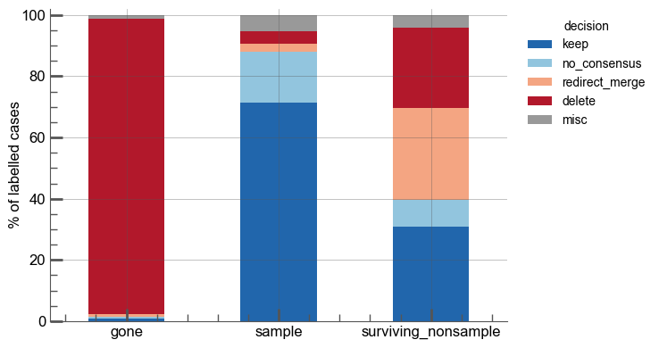

```python
dec_counts = (pd.concat({g: panel(D, g).decision_flat.value_counts() for g in three}, axis=1)
                .reindex(DEC_ORDER).fillna(0).astype(int))
print(dec_counts.to_string())
print("\nno parseable decision:",
      {g: int(panel(D, g).decision_flat.isna().sum()) for g in three})

share = 100 * dec_counts / dec_counts.sum()
a = share.T.plot.bar(stacked=True, rot=0, figsize=(7.5, 4), ylabel="% of labelled cases",
                     color=[DEC_COLORS[k] for k in DEC_ORDER])
a.legend(title="decision", bbox_to_anchor=(1.02, 1), loc="upper left", frameon=False)
a.figure.tight_layout()
```

The cases in our sample (~37k) have a distinct composition; a lot more of them are keep cases or were difficult to find consensus for.

```python
# a random 10 discussions per decision (all groups -- `grp` shows which side each came from)
show_cases(C, "decision_flat", DEC_ORDER)
```

keep (60,681 cases)

| afd_pageid | case_title | grp | afd_year | decision_flat | size_chars | dur_human_days | lat_median_h | n_discussants | n_editors | discussion |
| --- | --- | --- | --- | --- | --- | --- | --- | --- | --- | --- |
| 18737116 | ODD (One Document Does it all) | surviving_nonsample | 2008.0 | keep | 4400.0 | 7.69 | 1.12 | 8.0 | 9.0 | https://en.wikipedia.org/wiki/Wikipedia:Articles_for_deletion/ODD_(One_Document_Does_it_all) |
| 25372851 | Thomas Kaplan | surviving_nonsample | 2009.0 | keep | 2337.0 | 8.96 | 16.82 | 4.0 | 6.0 | https://en.wikipedia.org/wiki/Wikipedia:Articles_for_deletion/Thomas_Kaplan |
| 21605617 | Pékin Fine Arts | surviving_nonsample | 2009.0 | keep | 6703.0 | 4.63 | 1.76 | 12.0 | 13.0 | https://en.wikipedia.org/wiki/Wikipedia:Articles_for_deletion/Pékin_Fine_Arts |
| 30114693 | Takuo Kojima | surviving_nonsample | 2010.0 | keep | 5294.0 | 13.10 | 4.37 | 8.0 | 9.0 | https://en.wikipedia.org/wiki/Wikipedia:Articles_for_deletion/Takuo_Kojima |
| 25848240 | Tama Kurokawa | surviving_nonsample | 2010.0 | keep | 4440.0 | 1.87 | 4.87 | 6.0 | 6.0 | https://en.wikipedia.org/wiki/Wikipedia:Articles_for_deletion/Tama_Kurokawa |
| 47764930 | Dark Rome Tours & Walks | sample | 2015.0 | keep | 3358.0 | 6.61 | 11.38 | 5.0 | 7.0 | https://en.wikipedia.org/wiki/Wikipedia:Articles_for_deletion/Dark_Rome_Tours_&_Walks |
| 45539254 | Riachão (São Bento) | surviving_nonsample | 2015.0 | keep | 1232.0 | 0.59 | 7.06 | 1.0 | 2.0 | https://en.wikipedia.org/wiki/Wikipedia:Articles_for_deletion/Riachão_(São_Bento) |
| 55835025 | Star/Boom Boom | sample | 2017.0 | keep | 7459.0 | 22.95 | 12.33 | 7.0 | 9.0 | https://en.wikipedia.org/wiki/Wikipedia:Articles_for_deletion/Star/Boom_Boom |
| 58168785 | Hillfolk | surviving_nonsample | 2018.0 | keep | 18553.0 | 7.23 | 0.43 | 11.0 | 12.0 | https://en.wikipedia.org/wiki/Wikipedia:Articles_for_deletion/Hillfolk |
| 72427381 | Yuriy Dubrovin (actor) | surviving_nonsample | 2022.0 | keep | 3495.0 | 7.01 | 11.17 | 4.0 | 5.0 | https://en.wikipedia.org/wiki/Wikipedia:Articles_for_deletion/Yuriy_Dubrovin_(actor) |

no_consensus (16,759 cases)

| afd_pageid | case_title | grp | afd_year | decision_flat | size_chars | dur_human_days | lat_median_h | n_discussants | n_editors | discussion |
| --- | --- | --- | --- | --- | --- | --- | --- | --- | --- | --- |
| 10996350 | Socialist Party of Great Britain debates | sample | 2007.0 | no_consensus | 10267.0 | 9.09 | 2.90 | 16.0 | 17.0 | https://en.wikipedia.org/wiki/Wikipedia:Articles_for_deletion/Socialist_Party_of_Great_Britain_debates |
| 9445725 | Court calendar | surviving_nonsample | 2007.0 | no_consensus | 4830.0 | 6.34 | 17.62 | 8.0 | 9.0 | https://en.wikipedia.org/wiki/Wikipedia:Articles_for_deletion/Court_calendar |
| 16074753 | James Ogilvy | sample | 2008.0 | no_consensus | 12604.0 | 7.78 | 1.58 | 11.0 | 12.0 | https://en.wikipedia.org/wiki/Wikipedia:Articles_for_deletion/James_Ogilvy |
| 23516405 | Decommunization in Russia | sample | 2009.0 | no_consensus | 11304.0 | 7.73 | 0.21 | 16.0 | 17.0 | https://en.wikipedia.org/wiki/Wikipedia:Articles_for_deletion/Decommunization_in_Russia |
| 31217732 | AFL (Wii) | surviving_nonsample | 2011.0 | no_consensus | 8244.0 | 26.81 | 40.34 | 8.0 | 9.0 | https://en.wikipedia.org/wiki/Wikipedia:Articles_for_deletion/AFL_(Wii) |
| 43412952 | Computer Business Solutions (CBS) | gone | 2014.0 | no_consensus | 2551.0 | 21.73 | 159.62 | 2.0 | 4.0 | https://en.wikipedia.org/wiki/Wikipedia:Articles_for_deletion/Computer_Business_Solutions_(CBS) |
| 47793331 | 1950 Atlético Mineiro European tour | sample | 2015.0 | no_consensus | 13296.0 | 14.95 | 6.61 | 10.0 | 12.0 | https://en.wikipedia.org/wiki/Wikipedia:Articles_for_deletion/1950_Atlético_Mineiro_European_tour |
| 49126448 | 2305 | surviving_nonsample | 2016.0 | no_consensus | 5072.0 | 23.26 | 26.40 | 8.0 | 10.0 | https://en.wikipedia.org/wiki/Wikipedia:Articles_for_deletion/2305 |
| 52930780 | John and Elvis Are Dead | sample | 2017.0 | no_consensus | 6131.0 | 24.63 | 0.69 | 10.0 | 11.0 | https://en.wikipedia.org/wiki/Wikipedia:Articles_for_deletion/John_and_Elvis_Are_Dead |
| 67549651 | Aaron Maté | surviving_nonsample | 2021.0 | no_consensus | 18927.0 | 23.70 | 18.58 | 10.0 | 12.0 | https://en.wikipedia.org/wiki/Wikipedia:Articles_for_deletion/Aaron_Maté |

redirect_merge (33,899 cases)

| afd_pageid | case_title | grp | afd_year | decision_flat | size_chars | dur_human_days | lat_median_h | n_discussants | n_editors | discussion |
| --- | --- | --- | --- | --- | --- | --- | --- | --- | --- | --- |
| 16135668 | Brass Rings and Daydreams | surviving_nonsample | 2008.0 | redirect_merge | 3241.0 | 7.70 | 3.18 | 5.0 | 7.0 | https://en.wikipedia.org/wiki/Wikipedia:Articles_for_deletion/Brass_Rings_and_Daydreams |
| 27507951 | Yoyo@home | surviving_nonsample | 2010.0 | redirect_merge | 1618.0 | 5.60 | 34.57 | 3.0 | 5.0 | https://en.wikipedia.org/wiki/Wikipedia:Articles_for_deletion/Yoyo@home |
| 32038520 | Alfredo Di Stéfano Trophy (testimonial match) | surviving_nonsample | 2011.0 | redirect_merge | 2171.0 | 9.62 | 7.90 | 5.0 | 6.0 | https://en.wikipedia.org/wiki/Wikipedia:Articles_for_deletion/Alfredo_Di_Stéfano_Trophy_(testimonial_match) |
| 39411934 | Adobe OnLocation | surviving_nonsample | 2013.0 | redirect_merge | 4482.0 | 18.32 | 24.64 | 7.0 | 8.0 | https://en.wikipedia.org/wiki/Wikipedia:Articles_for_deletion/Adobe_OnLocation |
| 38642430 | The Stockyards Shopping Centre | surviving_nonsample | 2013.0 | redirect_merge | 3865.0 | 8.42 | 0.61 | 4.0 | 6.0 | https://en.wikipedia.org/wiki/Wikipedia:Articles_for_deletion/The_Stockyards_Shopping_Centre |
| 46586368 | 1777 Gehrels | sample | 2015.0 | redirect_merge | 4546.0 | 29.79 | 40.68 | 7.0 | 8.0 | https://en.wikipedia.org/wiki/Wikipedia:Articles_for_deletion/1777_Gehrels |
| 62047089 | Anirul | surviving_nonsample | 2019.0 | redirect_merge | 1989.0 | 7.37 | 11.43 | 2.0 | 4.0 | https://en.wikipedia.org/wiki/Wikipedia:Articles_for_deletion/Anirul |
| 63452937 | Jennifer Lamb Thompson | surviving_nonsample | 2020.0 | redirect_merge | 4729.0 | 22.32 | 74.40 | 6.0 | 8.0 | https://en.wikipedia.org/wiki/Wikipedia:Articles_for_deletion/Jennifer_Lamb_Thompson |
| 68309787 | Pierantonio Stiattesi | surviving_nonsample | 2021.0 | redirect_merge | 2573.0 | 7.23 | 25.72 | 3.0 | 5.0 | https://en.wikipedia.org/wiki/Wikipedia:Articles_for_deletion/Pierantonio_Stiattesi |
| 71512590 | Weinberg College of Arts and Sciences | surviving_nonsample | 2022.0 | redirect_merge | 4219.0 | 22.02 | 10.94 | 6.0 | 7.0 | https://en.wikipedia.org/wiki/Wikipedia:Articles_for_deletion/Weinberg_College_of_Arts_and_Sciences |

delete (216,545 cases)

| afd_pageid | case_title | grp | afd_year | decision_flat | size_chars | dur_human_days | lat_median_h | n_discussants | n_editors | discussion |
| --- | --- | --- | --- | --- | --- | --- | --- | --- | --- | --- |
| 14492044 | Science humour | gone | 2007.0 | delete | 7653.0 | 6.26 | 0.65 | 12.0 | 13.0 | https://en.wikipedia.org/wiki/Wikipedia:Articles_for_deletion/Science_humour |
| 15213226 | Saint John Mary International School | gone | 2008.0 | delete | 3350.0 | 6.48 | 6.91 | 6.0 | 7.0 | https://en.wikipedia.org/wiki/Wikipedia:Articles_for_deletion/Saint_John_Mary_International_School |
| 23417109 | The Metal Madman Radio Show | gone | 2009.0 | delete | 4506.0 | 20.42 | 35.31 | 6.0 | 7.0 | https://en.wikipedia.org/wiki/Wikipedia:Articles_for_deletion/The_Metal_Madman_Radio_Show |
| 27533137 | Jeff Franzmann | gone | 2010.0 | delete | 2194.0 | 7.01 | 25.41 | 3.0 | 5.0 | https://en.wikipedia.org/wiki/Wikipedia:Articles_for_deletion/Jeff_Franzmann |
| 30674292 | -ton | gone | 2011.0 | delete | 1000.0 | 0.30 | 3.56 | 0.0 | 2.0 | https://en.wikipedia.org/wiki/Wikipedia:Articles_for_deletion/-ton |
| 39358167 | Philips MCD395 | gone | 2013.0 | delete | 2147.0 | 14.41 | 33.33 | 4.0 | 6.0 | https://en.wikipedia.org/wiki/Wikipedia:Articles_for_deletion/Philips_MCD395 |
| 51598960 | FactoryFinder | gone | 2016.0 | delete | 3773.0 | 14.52 | 66.96 | 5.0 | 7.0 | https://en.wikipedia.org/wiki/Wikipedia:Articles_for_deletion/FactoryFinder |
| 53450006 | Abidoye Lukman Ayedeji | gone | 2017.0 | delete | 4006.0 | 7.64 | 3.30 | 6.0 | 8.0 | https://en.wikipedia.org/wiki/Wikipedia:Articles_for_deletion/Abidoye_Lukman_Ayedeji |
| 65610920 | Gareth Pass | gone | 2020.0 | delete | 2320.0 | 8.07 | 38.58 | 2.0 | 4.0 | https://en.wikipedia.org/wiki/Wikipedia:Articles_for_deletion/Gareth_Pass |
| 66018787 | Elizabeth Wakefield | surviving_nonsample | 2020.0 | delete | 4331.0 | 7.69 | 15.02 | 7.0 | 8.0 | https://en.wikipedia.org/wiki/Wikipedia:Articles_for_deletion/Elizabeth_Wakefield |

misc (8,576 cases)

| afd_pageid | case_title | grp | afd_year | decision_flat | size_chars | dur_human_days | lat_median_h | n_discussants | n_editors | discussion |
| --- | --- | --- | --- | --- | --- | --- | --- | --- | --- | --- |
| 13662520 | Samuel Gilbert Public School | surviving_nonsample | 2007.0 | misc | 2295.0 | 1.42 | 4.56 | 7.0 | 9.0 | https://en.wikipedia.org/wiki/Wikipedia:Articles_for_deletion/Samuel_Gilbert_Public_School |
| 19451973 | Writing in Space | surviving_nonsample | 2008.0 | misc | 4530.0 | 4.95 | 5.64 | 8.0 | 9.0 | https://en.wikipedia.org/wiki/Wikipedia:Articles_for_deletion/Writing_in_Space |
| 27118165 | Melbourne Storm salary cap scandal | surviving_nonsample | 2010.0 | misc | 4432.0 | 3.76 | 3.27 | 9.0 | 9.0 | https://en.wikipedia.org/wiki/Wikipedia:Articles_for_deletion/Melbourne_Storm_salary_cap_scandal |
| 29294665 | Weepul | surviving_nonsample | 2010.0 | misc | 3166.0 | 0.88 | 1.92 | 3.0 | 4.0 | https://en.wikipedia.org/wiki/Wikipedia:Articles_for_deletion/Weepul |
| 44307463 | Draft:Ajay Srinivasan | gone | 2014.0 | misc | 1131.0 | 0.44 | 10.61 | 0.0 | 2.0 | https://en.wikipedia.org/wiki/Wikipedia:Articles_for_deletion/Draft:Ajay_Srinivasan |
| 45709323 | User:Kevin Price | gone | 2015.0 | misc | 1386.0 | 0.03 | 0.71 | 0.0 | 2.0 | https://en.wikipedia.org/wiki/Wikipedia:Articles_for_deletion/User:Kevin_Price |
| 51041804 | Roca del toro | gone | 2016.0 | misc | 3888.0 | 14.04 | 0.46 | 5.0 | 5.0 | https://en.wikipedia.org/wiki/Wikipedia:Articles_for_deletion/Roca_del_toro |
| 56399558 | Atooi (disambiguation) | gone | 2018.0 | misc | 5104.0 | 0.50 | 1.25 | 4.0 | 6.0 | https://en.wikipedia.org/wiki/Wikipedia:Articles_for_deletion/Atooi_(disambiguation) |
| 61772893 | Gustáv Murín | sample | 2019.0 | misc | 3702.0 | 4.03 | 14.89 | 4.0 | 5.0 | https://en.wikipedia.org/wiki/Wikipedia:Articles_for_deletion/Gustáv_Murín |
| 65716956 | (Missing Women Commission of Inquiry) | gone | 2020.0 | misc | 1448.0 | 1.97 | 7.42 | 2.0 | 4.0 | https://en.wikipedia.org/wiki/Wikipedia:Articles_for_deletion/(Missing_Women_Commission_of_Inquiry) |

## Examinign surviving cases

```
decision_flat
keep              59084
no_consensus      15455
redirect_merge    32160
delete            29154
misc               6266
```

| decision_flat | size_chars | dur_human_days | lat_median_h | n_discussants |
| --- | --- | --- | --- | --- |
| keep | 4738.5 | 7.16 | 4.90 | 6.0 |
| no_consensus | 6002.0 | 20.58 | 10.56 | 7.0 |
| redirect_merge | 3588.0 | 7.98 | 9.32 | 5.0 |
| delete | 3191.0 | 7.32 | 8.06 | 5.0 |
| misc | 3470.0 | 1.72 | 2.09 | 4.0 |

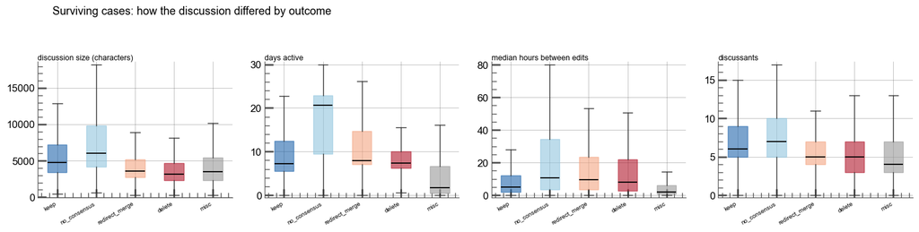

```python
# surviving cases only: the discussion, holding the article's fate fixed
Sy = D[D.grp.ne("gone")]
print(Sy.decision_flat.value_counts().reindex(DEC_ORDER).to_string())

fig, ax = plt.subplots(1, 4, figsize=(15, 3.8))
for a, col in zip(ax, HEADLINE):
    data = [Sy.loc[Sy.decision_flat.eq(k), col].dropna() for k in DEC_ORDER]
    bp = a.boxplot(data, showfliers=False, patch_artist=True, medianprops=dict(color="k", lw=1.3))
    for b, k in zip(bp["boxes"], DEC_ORDER):
        b.set_facecolor(DEC_COLORS[k]); b.set_alpha(.6); b.set_edgecolor(DEC_COLORS[k])
    a.set_xticks(range(1, len(DEC_ORDER) + 1), DEC_ORDER, rotation=30, ha="right", fontsize=7)
    a.set_title(LAB[col], loc="left", fontsize=9)
fig.suptitle("Surviving cases: how the discussion differed by outcome", x=.06, ha="left", fontsize=13)
fig.tight_layout(rect=[0, 0, 1, .9])

Sy.groupby("decision_flat")[HEADLINE].median().reindex(DEC_ORDER).round(2)
```

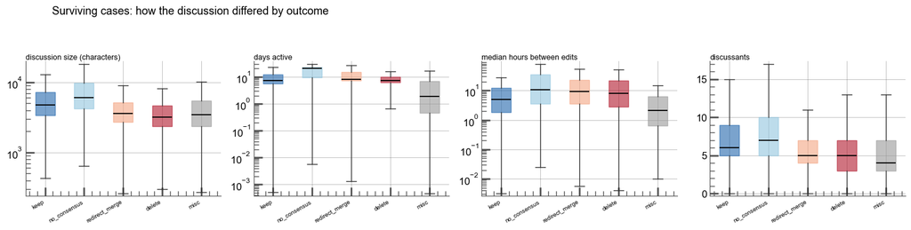

```python
# (logged)
fig, ax = plt.subplots(1, 4, figsize=(15, 3.8))
for a, col in zip(ax, HEADLINE):
    data = []
    for k in DEC_ORDER:
        x = Sy.loc[Sy.decision_flat.eq(k), col].dropna()
        data.append(x[x > 0] if col in LOGV else x)
    bp = a.boxplot(data, showfliers=False, patch_artist=True, medianprops=dict(color="k", lw=1.3))
    for b, k in zip(bp["boxes"], DEC_ORDER):
        b.set_facecolor(DEC_COLORS[k]); b.set_alpha(.6); b.set_edgecolor(DEC_COLORS[k])
    if col in LOGV:
        a.set_yscale("log")
    a.set_xticks(range(1, len(DEC_ORDER) + 1), DEC_ORDER, rotation=30, ha="right", fontsize=7)
    a.set_title(LAB[col], loc="left", fontsize=9)
fig.suptitle("Surviving cases: how the discussion differed by outcome", x=.06, ha="left", fontsize=13)
fig.tight_layout(rect=[0, 0, 1, .9])
```

## 5. The study sample

The 37k sample was carved out of the surviving cases by three filters: nomination year, article age at nomination, and clearing the topic-vector rough match. The slices below apply the first two on their own, so the difference each one makes is visible separately.

`uncensored` drops cases nominated after the dump ended, whose 30-day window is only partly observed so it's got incomplete data.

```python
slices = {
    "surviving (all)":                       S,
    "uncensored, all years":                 S[~S.censored],
    f"time only ({FIRST_YEAR}-{LAST_YEAR})": S[S.afd_year.between(FIRST_YEAR, LAST_YEAR)],
    "age only (>= 30d)":                     S[S.age_at_nom_days >= 30],
    "sample":                                S[S.grp.eq("sample")],
}
for k, v in slices.items():
    print(f"{k:34s} n={len(v):>7,}  pre-{FIRST_YEAR} {100*v.afd_year.lt(FIRST_YEAR).mean():5.1f}%  "
          f"censored {100*v.censored.mean():5.2f}%")

print(f"\nrecreated after their own nomination: {100*S.age_at_nom_days.lt(0).mean():.1f}% of surviving cases")
print("(the >= 30d filter removes all of them, since their age is negative)")

slice_med = pd.DataFrame({k: v[HEADLINE + ["n_editors"]].median() for k, v in slices.items()})
slice_med.loc["n_cases"] = [len(v) for v in slices.values()]
slice_med.round(2)
```

```
surviving (all)                    n=190,574  pre-2007  12.2%  censored  4.71%
uncensored, all years              n=181,607  pre-2007  12.8%  censored  0.00%
time only (2007-2022)              n=142,255  pre-2007   0.0%  censored  0.00%
age only (>= 30d)                  n= 96,443  pre-2007   6.4%  censored  7.27%
sample                             n= 37,597  pre-2007   0.0%  censored  0.00%

recreated after their own nomination: 31.5% of surviving cases
(the >= 30d filter removes all of them, since their age is negative)
```

|  | surviving (all) | uncensored, all years | time only (2007-2022) | age only (>= 30d) | sample |
| --- | --- | --- | --- | --- | --- |
| size_chars | 4187.00 | 4091.00 | 4162.00 | 4380.00 | 4667.00 |
| dur_human_days | 7.39 | 7.40 | 7.51 | 7.58 | 7.47 |
| lat_median_h | 5.94 | 5.94 | 6.57 | 7.08 | 6.24 |
| n_discussants | 6.00 | 6.00 | 6.00 | 6.00 | 6.00 |
| n_editors | 7.00 | 7.00 | 7.00 | 7.00 | 8.00 |
| n_cases | 190574.00 | 181607.00 | 142255.00 | 96443.00 | 37597.00 |

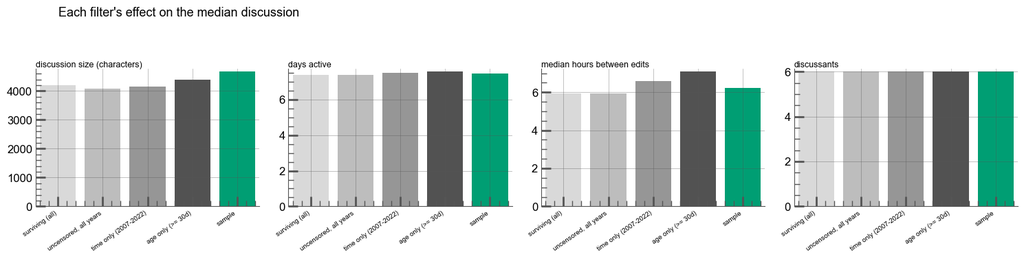

```python
fig, ax = plt.subplots(1, 4, figsize=(15, 3.8))
for a, col in zip(ax, HEADLINE):
    a.bar(range(len(slices)), [v[col].median() for v in slices.values()], color=SLICE_COLORS)
    a.set_xticks(range(len(slices)), list(slices), rotation=35, ha="right", fontsize=7)
    a.set_title(LAB[col], loc="left", fontsize=9)
fig.suptitle("Each filter's effect on the median discussion", x=.06, ha="left", fontsize=13)
fig.tight_layout(rect=[0, 0, 1, .9])
```

```python
# across measures
summary(HEADLINE + ["n_editors", "n_edits", "regular_share", "green_share"],
        groups=two)
```

|  | sample | surviving_nonsample | sample / nonsample |
| --- | --- | --- | --- |
| size_chars | 4667.0 (3331.0–7041.25) | 3977.0 (2808.0–6178.75) | 1.17 |
| dur_human_days | 7.47 (6.1–15.04) | 7.52 (6.37–14.16) | 0.99 |
| lat_median_h | 6.24 (2.19–16.59) | 6.7 (2.31–18.08) | 0.93 |
| n_discussants | 6.0 (4.0–8.0) | 6.0 (4.0–8.0) | 1.00 |
| n_editors | 8.0 (6.0–10.0) | 7.0 (6.0–10.0) | 1.14 |
| n_edits | 10.0 (7.0–14.0) | 9.0 (6.0–13.0) | 1.11 |
| regular_share | 0.67 (0.55–0.8) | 0.67 (0.5–0.8) | 1.00 |
| green_share | 0.07 (0.0–0.17) | 0.08 (0.0–0.17) | 0.86 |

My guess is that the difference between surviving cases in our sample and not in our sample is that sample has a greater proportion of keep and no_consensus cases, e.g., bringing size up.

```python
# sample vs nonsample within each decision: is the gap just the outcome mix?
COLS = HEADLINE + ["n_editors", "n_edits", "regular_share"]
Sv   = D[D.grp.isin(two)]
samp, non = panel(Sv, "sample"), panel(Sv, "surviving_nonsample")

# 1. within each decision: sample / nonsample median
med   = Sv.groupby(["decision_flat", "grp"])[COLS].median()
ratio = (med.xs("sample", level="grp") / med.xs("surviving_nonsample", level="grp")).reindex(DEC_ORDER)
n     = Sv.groupby(["decision_flat", "grp"]).size().unstack("grp").reindex(DEC_ORDER)
ratio.insert(0, "n_sample", n["sample"]); ratio.insert(1, "n_nonsample", n["surviving_nonsample"])
print("sample / nonsample median, within each decision")
display(ratio.round(2))
```

```
sample / nonsample median, within each decision
```

| decision_flat | n_sample | n_nonsample | size_chars | dur_human_days | lat_median_h | n_discussants | n_editors | n_edits | regular_share |
| --- | --- | --- | --- | --- | --- | --- | --- | --- | --- |
| keep | 26781 | 32303 | 0.96 | 1.01 | 1.22 | 0.86 | 1.00 | 1.00 | 1.05 |
| no_consensus | 6318 | 9137 | 0.93 | 1.22 | 1.55 | 0.88 | 0.89 | 0.92 | 1.07 |
| redirect_merge | 924 | 31236 | 1.03 | 1.02 | 1.03 | 1.00 | 1.00 | 1.00 | 0.98 |
| delete | 1532 | 27622 | 1.05 | 1.04 | 1.28 | 1.00 | 0.93 | 1.00 | 1.03 |
| misc | 2006 | 4260 | 1.06 | 0.98 | 1.06 | 1.00 | 1.00 | 1.00 | 1.06 |

```python
# 2. overall, with nonsample reweighted to the sample's decision mix
def wmedian(x, w):
    m = x.notna() & w.notna()
    x, w = x[m].to_numpy(), w[m].to_numpy()
    o = np.argsort(x); cw = np.cumsum(w[o])
    return x[o][np.searchsorted(cw, cw[-1] / 2)]

w = non.decision_flat.map(samp.decision_flat.value_counts(normalize=True)
                          / non.decision_flat.value_counts(normalize=True))   # unparsed -> NaN, dropped
adj = pd.DataFrame({
    "sample":               samp[COLS].median(),
    "nonsample":            non[COLS].median(),
    "nonsample, reweighted": pd.Series({c: wmedian(non[c], w) for c in COLS}),
})
adj["ratio (raw)"]      = adj["sample"] / adj["nonsample"]
adj["ratio (adjusted)"] = adj["sample"] / adj["nonsample, reweighted"]
print("overall, before and after matching nonsample to the sample's decision mix")
display(adj.round(2))
```

```
overall, before and after matching nonsample to the sample's decision mix
```

|  | sample | nonsample | nonsample, reweighted | ratio (raw) | ratio (adjusted) |
| --- | --- | --- | --- | --- | --- |
| size_chars | 4667.00 | 3977.00 | 4842.00 | 1.17 | 0.96 |
| dur_human_days | 7.47 | 7.52 | 7.37 | 0.99 | 1.01 |
| lat_median_h | 6.24 | 6.70 | 5.00 | 0.93 | 1.25 |
| n_discussants | 6.00 | 6.00 | 7.00 | 1.00 | 0.86 |
| n_editors | 8.00 | 7.00 | 8.00 | 1.14 | 1.00 |
| n_edits | 10.00 | 9.00 | 10.00 | 1.11 | 1.00 |
| regular_share | 0.67 | 0.67 | 0.67 | 1.00 | 1.00 |